# Part 4: Data Exploration and Statistics

# Setup

```r
library(ggplot2)
```

# Data

## Penguins

We’re going to use the same penguins data from previous days for the examples. If you don’t have it installed, you’ll need to uncomment the line below and do so.

```r
#install.packages("palmerpenguins")
```

If you have it installed, just load it:

```r
library(palmerpenguins)
```

## Housing Data

For a second data set, we’re going to use some data on houses and their sales prices

```r
install.packages("AmesHousing")
```

```r
library(AmesHousing)
names(ames_raw)
```

```
##  [1] "Order"           "PID"             "MS SubClass"     "MS Zoning"       "Lot Frontage"    "Lot Area"        "Street"
##  [8] "Alley"           "Lot Shape"       "Land Contour"    "Utilities"       "Lot Config"      "Land Slope"      "Neighborhood"
## [15] "Condition 1"     "Condition 2"     "Bldg Type"       "House Style"     "Overall Qual"    "Overall Cond"    "Year Built"
## [22] "Year Remod/Add"  "Roof Style"      "Roof Matl"       "Exterior 1st"    "Exterior 2nd"    "Mas Vnr Type"    "Mas Vnr Area"
## [29] "Exter Qual"      "Exter Cond"      "Foundation"      "Bsmt Qual"       "Bsmt Cond"       "Bsmt Exposure"   "BsmtFin Type 1"
## [36] "BsmtFin SF 1"    "BsmtFin Type 2"  "BsmtFin SF 2"    "Bsmt Unf SF"     "Total Bsmt SF"   "Heating"         "Heating QC"
## [43] "Central Air"     "Electrical"      "1st Flr SF"      "2nd Flr SF"      "Low Qual Fin SF" "Gr Liv Area"     "Bsmt Full Bath"
## [50] "Bsmt Half Bath"  "Full Bath"       "Half Bath"       "Bedroom AbvGr"   "Kitchen AbvGr"   "Kitchen Qual"    "TotRms AbvGrd"
## [57] "Functional"      "Fireplaces"      "Fireplace Qu"    "Garage Type"     "Garage Yr Blt"   "Garage Finish"   "Garage Cars"
## [64] "Garage Area"     "Garage Qual"     "Garage Cond"     "Paved Drive"     "Wood Deck SF"    "Open Porch SF"   "Enclosed Porch"
## [71] "3Ssn Porch"      "Screen Porch"    "Pool Area"       "Pool QC"         "Fence"           "Misc Feature"    "Misc Val"
## [78] "Mo Sold"         "Yr Sold"         "Sale Type"       "Sale Condition"  "SalePrice"
```

These variable names aren’t easy to type because of spaces and special characters. We wouldn’t be able to use them easily with the `$` syntax. I’m going to clean them up:

```r
install.packages("janitor")
```

I only need to use one function. Instead of loading the package, I’m going to prefix the function name with the package name:

```r
ames <- janitor::clean_names(ames_raw)
names(ames)
```

```
##  [1] "order"           "pid"             "ms_sub_class"    "ms_zoning"       "lot_frontage"    "lot_area"        "street"
##  [8] "alley"           "lot_shape"       "land_contour"    "utilities"       "lot_config"      "land_slope"      "neighborhood"
## [15] "condition_1"     "condition_2"     "bldg_type"       "house_style"     "overall_qual"    "overall_cond"    "year_built"
## [22] "year_remod_add"  "roof_style"      "roof_matl"       "exterior_1st"    "exterior_2nd"    "mas_vnr_type"    "mas_vnr_area"
## [29] "exter_qual"      "exter_cond"      "foundation"      "bsmt_qual"       "bsmt_cond"       "bsmt_exposure"   "bsmt_fin_type_1"
## [36] "bsmt_fin_sf_1"   "bsmt_fin_type_2" "bsmt_fin_sf_2"   "bsmt_unf_sf"     "total_bsmt_sf"   "heating"         "heating_qc"
## [43] "central_air"     "electrical"      "x1st_flr_sf"     "x2nd_flr_sf"     "low_qual_fin_sf" "gr_liv_area"     "bsmt_full_bath"
## [50] "bsmt_half_bath"  "full_bath"       "half_bath"       "bedroom_abv_gr"  "kitchen_abv_gr"  "kitchen_qual"    "tot_rms_abv_grd"
## [57] "functional"      "fireplaces"      "fireplace_qu"    "garage_type"     "garage_yr_blt"   "garage_finish"   "garage_cars"
## [64] "garage_area"     "garage_qual"     "garage_cond"     "paved_drive"     "wood_deck_sf"    "open_porch_sf"   "enclosed_porch"
## [71] "x3ssn_porch"     "screen_porch"    "pool_area"       "pool_qc"         "fence"           "misc_feature"    "misc_val"
## [78] "mo_sold"         "yr_sold"         "sale_type"       "sale_condition"  "sale_price"
```

These names are a bit harder to read, but they easier to type in R.

Let’s order the names

```r
sort(names(ames))
```

```
##  [1] "alley"           "bedroom_abv_gr"  "bldg_type"       "bsmt_cond"       "bsmt_exposure"   "bsmt_fin_sf_1"   "bsmt_fin_sf_2"
##  [8] "bsmt_fin_type_1" "bsmt_fin_type_2" "bsmt_full_bath"  "bsmt_half_bath"  "bsmt_qual"       "bsmt_unf_sf"     "central_air"
## [15] "condition_1"     "condition_2"     "electrical"      "enclosed_porch"  "exter_cond"      "exter_qual"      "exterior_1st"
## [22] "exterior_2nd"    "fence"           "fireplace_qu"    "fireplaces"      "foundation"      "full_bath"       "functional"
## [29] "garage_area"     "garage_cars"     "garage_cond"     "garage_finish"   "garage_qual"     "garage_type"     "garage_yr_blt"
## [36] "gr_liv_area"     "half_bath"       "heating"         "heating_qc"      "house_style"     "kitchen_abv_gr"  "kitchen_qual"
## [43] "land_contour"    "land_slope"      "lot_area"        "lot_config"      "lot_frontage"    "lot_shape"       "low_qual_fin_sf"
## [50] "mas_vnr_area"    "mas_vnr_type"    "misc_feature"    "misc_val"        "mo_sold"         "ms_sub_class"    "ms_zoning"
## [57] "neighborhood"    "open_porch_sf"   "order"           "overall_cond"    "overall_qual"    "paved_drive"     "pid"
## [64] "pool_area"       "pool_qc"         "roof_matl"       "roof_style"      "sale_condition"  "sale_price"      "sale_type"
## [71] "screen_porch"    "street"          "tot_rms_abv_grd" "total_bsmt_sf"   "utilities"       "wood_deck_sf"    "x1st_flr_sf"
## [78] "x2nd_flr_sf"     "x3ssn_porch"     "year_built"      "year_remod_add"  "yr_sold"
```

Now, make two variables that I want to use later:

Combine square footage measures into a new variable

```r
ames$sf <- ames$total_bsmt_sf + ames$x1st_flr_sf + ames$x2nd_flr_sf
```

And make an indicator variable for single family homes:

```r
ames$single_family <- ames$bldg_type == "1Fam"
```

## Today

So far we’ve learned how to get our data into a data frame, work with that data frame, and visualize that data. Now, how do we analyze it?

This isn’t a statistics workshop, so we’re going to focus on the code here. You’ll likely need to do more learning later about the specific models you use in your research. We have some additional workshops later this summer that also may be helpful for learning about running specific types of models in R.

# Summarize by Group

We learned how to subset our data frame, so if we want to compute a measure by group in our data, we could do it on subsets. But there are functions in R that will help us aggregate our data by categorical variables and compute summary measures.

First, `tapply`, which applies a function to a vector grouped by a second vector.

```r
tapply(vector to compute on,
       vector with groups,
       name of the function,
       optionally any arguments to the function besides the data vector)
```

```r
tapply(penguins$bill_length_mm,   # vector to compute on
       penguins$species,  # vector with groups
       mean,  # name of the function
       na.rm = TRUE)  # optionally any arguments to the function besides the data vector
```

```
##    Adelie Chinstrap    gentoo
##  38.78456  48.83382  47.50488
```

We can group by two different grouping variables by combining them in a list:

```r
tapply(penguins$bill_length_mm,   # vector to compute on
       list(penguins$species, penguins$island),  # vector with groups
       mean,  # name of the function
       na.rm = TRUE)  # optionally any arguments to the function besides the data vector
```

```
##             Biscoe    Dream Torgersen
## Adelie    38.97500 38.50179  38.93673
## Chinstrap       NA 48.83382        NA
## gentoo    47.50488       NA        NA
```

`aggregate()` is similar to `tapply` but produces output in a different format

```r
aggregate(penguins$bill_length_mm,  # data to compute on
          list(penguins$species, penguins$island),  # groups: it expects a list here
          mean,  # function
          na.rm=TRUE)   # additional arguments to the function
```

| Group.1 | Group.2 | x |
| --- | --- | --- |
| Adelie | Biscoe | 38.97500 |
| gentoo | Biscoe | 47.50488 |
| Adelie | Dream | 38.50179 |
| Chinstrap | Dream | 48.83382 |
| Adelie | Torgersen | 38.93673 |

We could also use the formula syntax we saw briefly while plotting, which happens to give us better names in the resulting data frame. It wants `variable ~ group1` or `variable ~ group1 + group2`, with `data` specified:

```r
aggregate(bill_length_mm ~ species + island,
          data = penguins,
          mean,
          na.rm=TRUE)
```

| species | island | bill_length_mm |
| --- | --- | --- |
| Adelie | Biscoe | 38.97500 |
| gentoo | Biscoe | 47.50488 |
| Adelie | Dream | 38.50179 |
| Chinstrap | Dream | 48.83382 |
| Adelie | Torgersen | 38.93673 |

```r
str(penguins)
```

```
## tibble [340 × 9] (S3: tbl_df/tbl/data.frame)
##  $ species          : Factor w/ 3 levels "Adelie","Chinstrap",..: 1 1 1 1 1 1 1 1 1 1 ...
##  $ island           : Factor w/ 3 levels "Biscoe","Dream",..: 3 3 3 3 3 3 3 3 3 3 ...
##  $ bill_length_mm   : num [1:340] 40.3 36.7 39.3 38.9 39.2 34.1 42 37.8 37.8 41.1 ...
##  $ bill_depth_mm    : num [1:340] 18 19.3 20.6 17.8 19.6 18.1 20.2 17.1 17.3 17.6 ...
##  $ flipper_length_mm: int [1:340] 195 193 190 181 195 193 190 186 180 182 ...
##  $ body_mass_g      : int [1:340] 3250 3450 3650 3625 4675 3475 4250 3300 3700 3200 ...
##  $ sex              : Factor w/ 2 levels "female","male": 1 1 2 1 2 NA NA NA NA 1 ...
##  $ year             : int [1:340] 2007 2007 2007 2007 2007 2007 2007 2007 2007 2007 ...
##  $ bill_length_cm   : num [1:340] 4.03 3.67 3.93 3.89 3.92 3.41 4.2 3.78 3.78 4.11 ...
```

### EXERCISE

Compute group means of `body_mass_g` by `sex` with `tapply()` and `aggregate()`.

Use `tapply()`

Use `aggregate()`

# Correlation

```r
cor(penguins$bill_depth_mm, penguins$bill_length_mm)
```

[output not shown]

Those missing values again!

```r
cor(penguins$bill_depth_mm, penguins$bill_length_mm,
    use = "pairwise")
```

```
## [1] -0.2334203
```

There are different methods. Default (above) is pearson – “normal” correlation for continuous variables.

There are also rank (non-parametric) correlations:

```r
cor(penguins$bill_depth_mm, penguins$bill_length_mm,
    use = "pairwise",
    method = "kendall")
```

```
## [1] -0.1214345
```

```r
cor(penguins$bill_depth_mm, penguins$bill_length_mm,
    use = "pairwise",
    method = "spearman")
```

```
## [1] -0.2197588
```

Is our correlation “significant”?

```r
cor.test(penguins$bill_depth_mm, penguins$bill_length_mm,
    use = "pairwise")
```

```
##
##  Pearson's product-moment correlation
##
## data:  penguins$bill_depth_mm and penguins$bill_length_mm
## t = -4.4133, df = 338, p-value = 1.371e-05
## alternative hypothesis: true correlation is not equal to 0
## 95 percent confidence interval:
##  -0.3315510 -0.1302929
## sample estimates:
##        cor
## -0.2334203
```

This seems strange that there’s a negative correlation between these measures. Let’s look at the data:

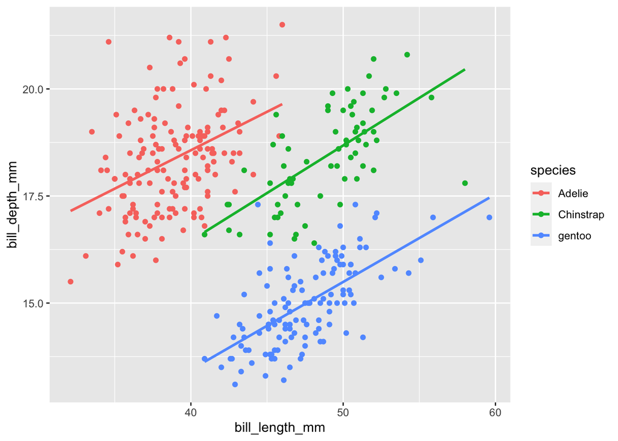

```r
ggplot(penguins, aes(x=bill_length_mm,
                     y=bill_depth_mm,
                     color=species)) +
  geom_point() +
  geom_smooth(method="lm", se=FALSE)
```

What’s going on? Simpson’s Paradox. The relationship in the groups is different within groups vs. overall.

We need to compute the correlation separately for each group. Unfortunately, `tapply()` and `aggregate()` don’t work, because `cor()` expects two vectors to compute a single correlation.

There are multiple ways we could do this, including a [function](https://personality-project.org/r/html/statsBy.html) in the `psych` package (written by Northwestern’s own Bill Revelle) that will let you compute correlation and other statistics by group.

Or we could do it manually here for practice subsetting data!

### EXERCISE

```r
cor(___, ___,
    use = "pairwise")
cor(___, ___,
    use = "pairwise")
cor(___, ___,
    use = "pairwise")
```

We can also use `cor()` to compute a correlation matrix between multiple variables at once by supplying a data frame or matrix instead of two vectors.

```r
# Which are the numeric variables?
head(penguins)
```

| species | island | bill_length_mm | bill_depth_mm | flipper_length_mm | body_mass_g | sex | year | bill_length_cm |
| --- | --- | --- | --- | --- | --- | --- | --- | --- |
| Adelie | Torgersen | 40.3 | 18.0 | 195 | 3250 | female | 2007 | 4.03 |
| Adelie | Torgersen | 36.7 | 19.3 | 193 | 3450 | female | 2007 | 3.67 |
| Adelie | Torgersen | 39.3 | 20.6 | 190 | 3650 | male | 2007 | 3.93 |
| Adelie | Torgersen | 38.9 | 17.8 | 181 | 3625 | female | 2007 | 3.89 |
| Adelie | Torgersen | 39.2 | 19.6 | 195 | 4675 | male | 2007 | 3.92 |
| Adelie | Torgersen | 34.1 | 18.1 | 193 | 3475 | NA | 2007 | 3.41 |

Correlation of just the numeric columns

```r
cor(penguins[,3:6],
    use = "pairwise")
```

```
##                   bill_length_mm bill_depth_mm flipper_length_mm body_mass_g
## bill_length_mm         1.0000000    -0.2334203         0.6543670   0.5942024
## bill_depth_mm         -0.2334203     1.0000000        -0.5834221  -0.4712592
## flipper_length_mm      0.6543670    -0.5834221         1.0000000   0.8720447
## body_mass_g            0.5942024    -0.4712592         0.8720447   1.0000000
```

Correlation just for a subgroup – choosing a subset of rows

```r
cor(penguins[penguins$species=="Chinstrap",3:6],
    use = "pairwise")
```

```
##                   bill_length_mm bill_depth_mm flipper_length_mm body_mass_g
## bill_length_mm         1.0000000     0.6535362         0.4716073   0.5136383
## bill_depth_mm          0.6535362     1.0000000         0.5801429   0.6044983
## flipper_length_mm      0.4716073     0.5801429         1.0000000   0.6415594
## body_mass_g            0.5136383     0.6044983         0.6415594   1.0000000
```

# T-Test

A t-test lets us determine if the means of two groups are statistically different from each other. If we have a variable that splits our data into two groups, we can use the formula syntax here `variable ~ groups`:

```r
t.test(body_mass_g ~ sex, data=penguins)
```

```
##
##  Welch Two Sample t-test
##
## data:  body_mass_g by sex
## t = -8.573, df = 322.23, p-value = 4.279e-16
## alternative hypothesis: true difference in means between group female and group male is not equal to 0
## 95 percent confidence interval:
##  -845.6342 -529.9591
## sample estimates:
## mean in group female   mean in group male
##             3862.652             4550.449
```

Or we can supply two separate vectors of values to compare:

```r
# same as above
t.test(penguins$body_mass_g[penguins$sex == "male"],
       penguins$body_mass_g[penguins$sex == "female"])
```

```
##
##  Welch Two Sample t-test
##
## data:  penguins$body_mass_g[penguins$sex == "male"] and penguins$body_mass_g[penguins$sex == "female"]
## t = 8.573, df = 322.23, p-value = 4.279e-16
## alternative hypothesis: true difference in means is not equal to 0
## 95 percent confidence interval:
##  529.9591 845.6342
## sample estimates:
## mean of x mean of y
##  4550.449  3862.652
```

### EXERCISE

Using the `ames` data, do `single_family` homes have greater `sf` (square footage) than other types of homes?

# Regression

To compute a linear regression, we use the `lm()` function (linear model) and the special formula syntax

```r
reg1 <- lm(sale_price ~ bedroom_abv_gr + full_bath + half_bath + tot_rms_abv_grd + sf,
           data = ames)
reg1
```

```
##
## Call:
## lm(formula = sale_price ~ bedroom_abv_gr + full_bath + half_bath +
##     tot_rms_abv_grd + sf, data = ames)
##
## Coefficients:
##     (Intercept)   bedroom_abv_gr        full_bath        half_bath  tot_rms_abv_grd               sf
##         1472.83        -22299.80         25147.29         19527.52          2523.48            70.65
```

```r
summary(reg1)
```

```
##
## Call:
## lm(formula = sale_price ~ bedroom_abv_gr + full_bath + half_bath +
##     tot_rms_abv_grd + sf, data = ames)
##
## Residuals:
##     Min      1Q  Median      3Q     Max
## -704985  -20785    -844   19615  244911
##
## Coefficients:
##                   Estimate Std. Error t value Pr(>|t|)
## (Intercept)       1472.831   3717.656   0.396  0.69201
## bedroom_abv_gr  -22299.799   1375.608 -16.211  < 2e-16 ***
## full_bath        25147.295   1895.583  13.266  < 2e-16 ***
## half_bath        19527.521   1760.386  11.093  < 2e-16 ***
## tot_rms_abv_grd   2523.483    923.494   2.733  0.00632 **
## sf                  70.652      1.486  47.531  < 2e-16 ***
## ---
## Signif. codes:  0 '***' 0.001 '**' 0.01 '*' 0.05 '.' 0.1 ' ' 1
##
## Residual standard error: 44850 on 2923 degrees of freedom
##   (1 observation deleted due to missingness)
## Multiple R-squared:  0.6853, Adjusted R-squared:  0.6847
## F-statistic:  1273 on 5 and 2923 DF,  p-value: < 2.2e-16
```

```r
names(reg1)
```

```
##  [1] "coefficients"  "residuals"     "effects"       "rank"          "fitted.values" "assign"        "qr"            "df.residual"
##  [9] "na.action"     "xlevels"       "call"          "terms"         "model"
```

```r
names(summary(reg1))
```

```
##  [1] "call"          "terms"         "residuals"     "coefficients"  "aliased"       "sigma"         "df"            "r.squared"
##  [9] "adj.r.squared" "fstatistic"    "cov.unscaled"  "na.action"
```

```r
summary(reg1)$coefficients
```

```
##                     Estimate  Std. Error    t value     Pr(>|t|)
## (Intercept)       1472.83102 3717.655576   0.396172 6.920071e-01
## bedroom_abv_gr  -22299.79852 1375.608127 -16.210866 1.163269e-56
## full_bath        25147.29459 1895.582967  13.266259 4.777531e-39
## half_bath        19527.52055 1760.385608  11.092752 4.894246e-28
## tot_rms_abv_grd   2523.48261  923.493859   2.732539 6.322635e-03
## sf                  70.65248    1.486457  47.530796 0.000000e+00
```

### EXERCISE

Run a linear regression model with the dependent (y, outcome) variable of `sf` (square footage), and independent (x, predictor) variables of `lot_area` and `tot_rms_abv_grd`. Print the summary of the model.

## Categorical Variables

```r
table(ames$house_style)
```

```
##
## 1.5Fin 1.5Unf 1Story 2.5Fin 2.5Unf 2Story SFoyer   SLvl
##    314     19   1481      8     24    873     83    128
```

What if we put `house_style` into our regression?

```r
reg2 <- lm(sale_price ~ bedroom_abv_gr + full_bath + half_bath +
             tot_rms_abv_grd + sf + house_style,
           data = ames)
summary(reg2)
```

```
##
## Call:
## lm(formula = sale_price ~ bedroom_abv_gr + full_bath + half_bath +
##     tot_rms_abv_grd + sf + house_style, data = ames)
##
## Residuals:
##     Min      1Q  Median      3Q     Max
## -701323  -20667    -954   19096  246249
##
## Coefficients:
##                     Estimate Std. Error t value Pr(>|t|)
## (Intercept)       -19082.200   4916.011  -3.882 0.000106 ***
## bedroom_abv_gr    -21261.666   1378.852 -15.420  < 2e-16 ***
## full_bath          23630.946   1970.964  11.990  < 2e-16 ***
## half_bath          19405.285   2192.055   8.853  < 2e-16 ***
## tot_rms_abv_grd     3464.917    958.433   3.615 0.000305 ***
## sf                    69.714      1.578  44.169  < 2e-16 ***
## house_style1.5Unf  10220.085  10580.983   0.966 0.334178
## house_style1Story  18672.347   2906.984   6.423 1.55e-10 ***
## house_style2.5Fin  10744.654  16103.257   0.667 0.504675
## house_style2.5Unf -12381.553   9493.673  -1.304 0.192272
## house_style2Story  16667.479   3318.189   5.023 5.39e-07 ***
## house_styleSFoyer  26415.498   5599.144   4.718 2.50e-06 ***
## house_styleSLvl    27287.398   4686.920   5.822 6.45e-09 ***
## ---
## Signif. codes:  0 '***' 0.001 '**' 0.01 '*' 0.05 '.' 0.1 ' ' 1
##
## Residual standard error: 44410 on 2916 degrees of freedom
##   (1 observation deleted due to missingness)
## Multiple R-squared:  0.6921, Adjusted R-squared:  0.6909
## F-statistic: 546.3 on 12 and 2916 DF,  p-value: < 2.2e-16
```

But look closely at the variables in the summary above – the values for `house_style`. What’s going on?

To address this:

```r
reg3 <- lm(sale_price ~ -1 + bedroom_abv_gr + full_bath + half_bath +
             tot_rms_abv_grd + sf + house_style,
           data = ames)
summary(reg3)
```

```
##
## Call:
## lm(formula = sale_price ~ -1 + bedroom_abv_gr + full_bath + half_bath +
##     tot_rms_abv_grd + sf + house_style, data = ames)
##
## Residuals:
##     Min      1Q  Median      3Q     Max
## -701323  -20667    -954   19096  246249
##
## Coefficients:
##                     Estimate Std. Error t value Pr(>|t|)
## bedroom_abv_gr    -21261.666   1378.852 -15.420  < 2e-16 ***
## full_bath          23630.946   1970.964  11.990  < 2e-16 ***
## half_bath          19405.285   2192.055   8.853  < 2e-16 ***
## tot_rms_abv_grd     3464.917    958.433   3.615 0.000305 ***
## sf                    69.714      1.578  44.169  < 2e-16 ***
## house_style1.5Fin -19082.200   4916.011  -3.882 0.000106 ***
## house_style1.5Unf  -8862.115  10618.663  -0.835 0.404023
## house_style1Story   -409.853   3939.825  -0.104 0.917154
## house_style2.5Fin  -8337.546  17067.784  -0.488 0.625235
## house_style2.5Unf -31463.753  10562.422  -2.979 0.002917 **
## house_style2Story  -2414.720   5317.911  -0.454 0.649810
## house_styleSFoyer   7333.298   5833.614   1.257 0.208827
## house_styleSLvl     8205.198   5685.120   1.443 0.149050
## ---
## Signif. codes:  0 '***' 0.001 '**' 0.01 '*' 0.05 '.' 0.1 ' ' 1
##
## Residual standard error: 44410 on 2916 degrees of freedom
##   (1 observation deleted due to missingness)
## Multiple R-squared:  0.9497, Adjusted R-squared:  0.9495
## F-statistic:  4239 on 13 and 2916 DF,  p-value: < 2.2e-16
```

## Formula Syntax

```
Symbol   Example            Description
------------------------------------------------------------------------------------------------
~        y ~ x1             Defines the formula (necessary to create a formula object)
+        y ~ x1 + x2        Include the variable
-        y ~ -1 + x1        Delete a term, usually a 1 for the intercept
:        y ~ x1 + x1:x2     Interaction term
*        y ~ x1*x2          Interaction between the variables and each term individually;
                              same as y ~ x1 + x2 + x1:x2
I()      y ~ I(log(x1))     Wrapper for transforming variables without creating a new variable
poly()   y ~ poly(x1, 2)    Creates polynomial terms up to the degree specified
```

Let’s add an interaction term:

```r
reg4 <- lm(sale_price ~ -1 + bedroom_abv_gr + full_bath + half_bath +
             tot_rms_abv_grd*sf + house_style,
           data = ames)
summary(reg4)
```

```
##
## Call:
## lm(formula = sale_price ~ -1 + bedroom_abv_gr + full_bath + half_bath +
##     tot_rms_abv_grd * sf + house_style, data = ames)
##
## Residuals:
##     Min      1Q  Median      3Q     Max
## -552676  -21601    -924   19569  283039
##
## Coefficients:
##                      Estimate Std. Error t value Pr(>|t|)
## bedroom_abv_gr     -2.260e+04  1.364e+03 -16.567  < 2e-16 ***
## full_bath           2.005e+04  1.974e+03  10.153  < 2e-16 ***
## half_bath           1.794e+04  2.163e+03   8.297  < 2e-16 ***
## tot_rms_abv_grd     1.471e+04  1.490e+03   9.873  < 2e-16 ***
## sf                  1.013e+02  3.590e+00  28.209  < 2e-16 ***
## house_style1.5Fin  -9.329e+04  9.017e+03 -10.346  < 2e-16 ***
## house_style1.5Unf  -7.765e+04  1.261e+04  -6.158 8.36e-10 ***
## house_style1Story  -7.443e+04  8.523e+03  -8.733  < 2e-16 ***
## house_style2.5Fin  -7.134e+04  1.800e+04  -3.964 7.55e-05 ***
## house_style2.5Unf  -1.055e+05  1.287e+04  -8.194 3.73e-16 ***
## house_style2Story  -7.416e+04  9.029e+03  -8.214 3.19e-16 ***
## house_styleSFoyer  -6.276e+04  9.199e+03  -6.822 1.08e-11 ***
## house_styleSLvl    -6.498e+04  9.361e+03  -6.942 4.76e-12 ***
## tot_rms_abv_grd:sf -4.043e+00  4.146e-01  -9.752  < 2e-16 ***
## ---
## Signif. codes:  0 '***' 0.001 '**' 0.01 '*' 0.05 '.' 0.1 ' ' 1
##
## Residual standard error: 43710 on 2915 degrees of freedom
##   (1 observation deleted due to missingness)
## Multiple R-squared:  0.9513, Adjusted R-squared:  0.9511
## F-statistic:  4070 on 14 and 2915 DF,  p-value: < 2.2e-16
```

### EXERCISE

Run a linear regression model to predict `sf` (square footage) using `lot_area`, `tot_rms_abv_grd`, and an interaction between `fence` and `garage_type`. (Yes, this is a fairly non-sensical model :) )

# Coming Up

The statistical methods and models people use varies considerably across fields. The independent work resource for today comes from a book developed specifically for psychology students, so it may or may not contain the methods that you need for your work. This workshop isn’t about learning new statistical techniques, so please do skip any material that isn’t relevant to you. If you need help finding resources for your specific field or type of analysis, please ask on the discussion boards.